# W3cubDocs

/Cypress

# Browser Launch API

Before Cypress launches a browser, it gives you the opportunity to modify the browser preferences, install extensions, add and remove command-line arguments, and modify other options from your [`pluginsFile`](https://docs.cypress.io/guides/tooling/plugins-guide.html).

# Syntax

```javascript
on('before:browser:launch', (browser = {}, launchOptions) => { /* ... */ })
```

**browser** *(object)*

An object describing the browser being launched, with the following properties:

| Property | Type | Description |
| --- | --- | --- |
| `name` | `string` | Machine-friendly name, like `chrome`, `electron`, or `firefox`. |
| `family` | `string` | Rendering engine being used. `chromium` or `firefox`. |
| `channel` | `string` | Release channel of the browser, such as `stable`, `dev`, or `canary`. |
| `displayName` | `string` | Human-readable display name for the browser. |
| `version` | `string` | Full version. |
| `path` | `string` | Path to the browser on disk. Blank for Electron. |
| `info` | `string` | *(Optional)* Extra information about the browser (used for display in the browser selector of the Test Runner) |
| `majorVersion` | `number` | The major version number of the browser. |
| `isHeadless` | `boolean` | Whether the browser is running headlessly. |
| `isHeaded` | `boolean` | Whether the browser displays headed. |

**launchOptions** *(object)*

Options that can be modified to control how the browser is launched, with the following properties:

[output not shown]

# Usage

## Modify browser launch arguments, preferences, and extensions

Using your [`pluginsFile`](https://docs.cypress.io/guides/tooling/plugins-guide.html) you can tap into the `before:browser:launch` event and modify how Cypress launches the browser (e.g. modify arguments, user preferences, and extensions).

This event will yield you the `browser` object, which gives you information about the browser, and the `launchOptions` object, which allows you to modify how the browser is launched.

The returned `launchOptions` object will become the new launch options for the browser.

### Modify browser launch arguments:

Here are args available for the currently supported browsers:

- [Chromium-based browsers](https://peter.sh/experiments/chromium-command-line-switches/)
- [Firefox](https://developer.mozilla.org/docs/Mozilla/Command_Line_Options)

```javascript
// cypress/plugins/index.js
module.exports = (on, config) => {
  on('before:browser:launch', (browser = {}, launchOptions) => {
    // `args` is an array of all the arguments that will
    // be passed to browsers when it launches
    console.log(launchOptions.args) // print all current args

    if (browser.family === 'chromium' && browser.name !== 'electron') {
      // auto open devtools
      launchOptions.args.push('--auto-open-devtools-for-tabs')

      // whatever you return here becomes the launchOptions
      return launchOptions
    }

    if (browser.family === 'firefox') {
      // auto open devtools
      launchOptions.args.push('-devtools')

      return launchOptions
    }
  })
}
```

### Add browser extensions:

```javascript
// cypress/plugins/index.js
module.exports = (on, config) => {
  on('before:browser:launch', (browser, launchOptions) => {
    // supply the absolute path to an unpacked extension's folder
    // NOTE: extensions cannot be loaded in headless Chrome
    launchOptions.extensions.push('Users/jane/path/to/extension')

    return launchOptions
  })
}
```

### Changing browser preferences:

Here are preferences available for the currently supported browsers:

- [Chromium-based browsers](https://src.chromium.org/viewvc/chrome/trunk/src/chrome/common/pref_names.cc?view=markup)
- [Electron](https://github.com/electron/electron/blob/master/docs/api/browser-window.md#new-browserwindowoptions)
- Firefox: visit `about:config` URL within your Firefox browser to see all available preferences.

```javascript
// cypress/plugins/index.js
module.exports = (on, config) => {
  on('before:browser:launch', (browser, launchOptions) => {
    if (browser.family === 'chromium' && browser.name !== 'electron') {
      // in Chromium, preferences can exist in Local State, Preferences, or Secure Preferences
      // via launchOptions.preferences, these can be acccssed as `localState`, `default`, and `secureDefault`

      // for example, to set `somePreference: true` in Preferences:
      launchOptions.preferences.default['preference'] = true

      return launchOptions
    }

    if (browser.family === 'firefox') {
      // launchOptions.preferences is a map of preference names to values
      launchOptions.preferences['some.preference'] = true

      return launchOptions
    }

    if (browser.name === 'electron') {
      // launchOptions.preferences is a `BrowserWindow` `options` object
      launchOptions.preferences.darkTheme = true

      return launchOptions
    }
  })
}
```

## Modify Electron app switches

Cypress Test Runner is an Electron application, and its behavior (and the behavior of the bundled-in Electron browser) can be customized using command line switches. The supported switches depend on the Electron version, see [Electron documentation](https://www.electronjs.org/docs/api/command-line-switches).

### Linux/OSX

```bash
export ELECTRON_EXTRA_LAUNCH_ARGS=--disable-http-cache --lang=es
```

### Windows

```bash
set ELECTRON_EXTRA_LAUNCH_ARGS=--disable-http-cache --lang=es
```

Cypress already sets some the Electron command line switches internally. See file packages/server/lib/environment.js. There is no way to see all currently set switches after Electron’s launch.

## See all Chrome browser switches

If you are running Cypress tests using a Chromium-based browser, you can see ALL currently set command line switches and the browser version information by opening a new tab and typing `chrome://version` url.

[figure not shown]

# Examples

## Set screen size when running headless

When a browser runs headless, there is no physical display. You can override the default screen size of 1280x720 when running headless as shown below. This will affect the size of screenshots and videos taken during the run.

> This setting changes the display size of the screen and does not affect the `viewportWidth` and `viewportHeight` set in the [configuration](https://docs.cypress.io/guides/references/configuration.html). The `viewportWidth` and `viewportHeight` only affect the size of the application under test displayed inside the Test Runner.

```javascript
// cypress/plugins/index.js
module.exports = (on, config) => {
  on('before:browser:launch', (browser, launchOptions) => {
    if (browser.name === 'chrome' && browser.isHeadless) {
      // fullPage screenshot size is 1400x1200 on non-retina screens
      // and 2800x2400 on retina screens
      launchOptions.args.push('--window-size=1400,1200')

      // force screen to be non-retina (1400x1200 size)
      launchOptions.args.push('--force-device-scale-factor=1')

      // force screen to be retina (2800x2400 size)
      // launchOptions.args.push('--force-device-scale-factor=2')
    }

    if (browser.name === 'electron' && browser.isHeadless) {
      // fullPage screenshot size is 1400x1200
      launchOptions.preferences.width = 1400
      launchOptions.preferences.height = 1200
    }

    if (browser.name === 'firefox' && browser.isHeadless) {
      // menubars take up height on the screen
      // so fullPage screenshot size is 1400x1126
      launchOptions.args.push('--width=1400')
      launchOptions.args.push('--height=1200')
    }

    return launchOptions
  })
}
```

## Start fullscreen

```javascript
// cypress/plugins/index.js
module.exports = (on, config) => {
  on('before:browser:launch', (browser = {}, launchOptions) => {
    if (browser.family === 'chromium' && browser.name !== 'electron') {
      launchOptions.args.push('--start-fullscreen')

      return launchOptions
    }

    if (browser.name === 'electron') {
      launchOptions.preferences.fullscreen = true

      return launchOptions
    }
  })
}
```

## Use fake video for webcam testing

By default, Cypress passes the Chrome command line switch to enable a fake video for a media stream. This is to better enable testing webcam functionality without having to have the necessary hardware to test.

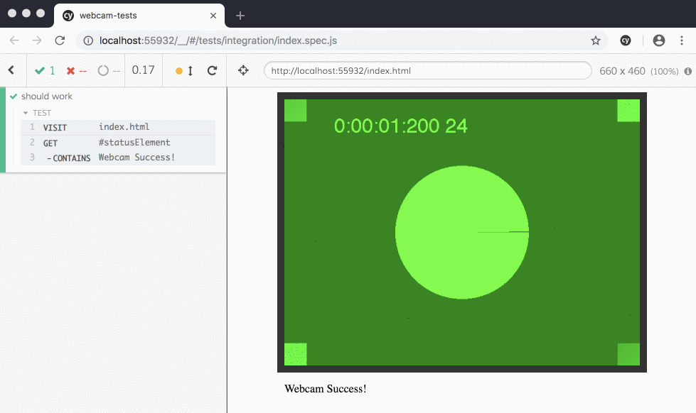

You can however send your own video file for testing by passing a Chrome command line switch pointing to a video file.

```javascript
// cypress/plugins/index.js
module.exports = (on, config) => {
  on('before:browser:launch', (browser = {}, launchOptions) => {
    if (browser.family === 'chromium' && browser.name !== 'electron') {
      // Mac/Linux
      launchOptions.args.push('--use-file-for-fake-video-capture=cypress/fixtures/my-video.y4m')

      // Windows
      // launchOptions.args.push('--use-file-for-fake-video-capture=c:\\path\\to\\video\\my-video.y4m')
    }

    return launchOptions
  })
}
```

## Change download directory

Change the download directory of files downloaded during Cypress tests.

```javascript
// cypress/plugins/index.js
const path = require('path')

module.exports = (on) => {
  on('before:browser:launch', (browser, options) => {
    const downloadDirectory = path.join(__dirname, '..', 'downloads')

    if (browser.family === 'chromium' && browser.name !== 'electron') {
      options.preferences.default['download'] = { default_directory: downloadDirectory }

      return options
    }

    if (browser.family === 'firefox') {
      options.preferences['browser.download.dir'] = downloadDirectory
      options.preferences['browser.download.folderList'] = 2

      // needed to prevent download prompt for text/csv files.
      options.preferences['browser.helperApps.neverAsk.saveToDisk'] = 'text/csv'

      return options
    }
  })
}
```

> [Check out our example recipe showing how to download and validate CSV and Excel files.](https://docs.cypress.io/examples/examples/recipes.html#Testing-the-DOM)

# History

| Version | Changes |
| --- | --- |
| [4.0.0](https://docs.cypress.io/guides/references/changelog.html#4-0-0) | New `options` object replaces old `args` as second argument to `before:browser:launch` |
| [4.0.0](https://docs.cypress.io/guides/references/changelog.html#4-0-0) | All Chromium-based browsers, including Electron, have `chromium` set as their `family` property. |
| [4.0.0](https://docs.cypress.io/guides/references/changelog.html#4-0-0) | Added `channel` property to browser. |

© 2020 Cypress.io  
Licensed under the MIT License.  
https://docs.cypress.io/api/plugins/browser-launch-api.html